# Analyse COVID data

Hanne Oberman

2023-09-06

# 1 Packages and functions used

```r
# set random number generator
set.seed(11)

# setup environment
library(haven)      # For importing SPSS data
library(readxl)     # For reading excel files
library(plyr)       # Data wrangling
library(dplyr)      # Data wrangling improved
library(mice)       # For incomplete data analysis
library(miceadds)   # Additions to mice
library(ggmice)     # Plotting device for mice
library(lme4)       # Linear mixed-effect modeling
library(magrittr)   # Pipes in R
library(lme4)       # linear mixed effects models
library(broom.mixed)# tidy and glance models for mixed effects classes
library(purrr)      # functional programming
library(tidyr)      # functional programming
library(DT)         # interactive tables
library(hardhat)    # weighted tables
library(weights)    # weighted chi square test
```

# 2 Read in the incomplete data

Import the imputed data.

```r
imp <- readRDS("../Data/imp_20it.RDS")
long <- mice::complete(imp, "long", include = TRUE)
```

Import the incomplete data to match the weights in the `weegfactor` variable.

```r
load("../Data/clean.Rdata")
```

Add weights to the imputed data.

```r
long <- left_join(long, unique(dat_clean[, c("id", "weegfactor")]), by= "id")
```

Load relevant variables.

```r
vars_outcome <- c("q60_1", "q49_1", "q49_2", "q49_3", "q49_4", "q49_5", "q49_6")
vars_fixed <- c("weegfactor", "edu", "age", "q29", "q52", "q53", "q54", "sekse", "etn_herkomst")
vars_random <- c("meting_mnd", "meting_squared", "q43", "q48_1", "q48_9", "q48_10", "q48_11", "q48_12", "q47_1", "q47_2", "q47_3", "q33_1", "q33_2", "q33_3", "q33_4", "q33_5", "q33_6")
vars_covariates <- c("q34_1", "q34_2", "q34_3", "q34_4", "q34_5", "q38_1", "q38_2", "q38_3", "q38_4", "q31_1", "q31_2", "q31_3", "q31_4", "q31_5", "q31_6", "q31_7", "q59", "q60_2", "q60_3", "q60_4", "q60_8", "q60_10", "q60_12")
vars_analyse <- c("id", vars_fixed, vars_outcome, vars_random)
```

# 3 Post-processing the variables

Label factor levels. See Analysis.Rdm for details.

```r
# Merge small categories
long$q29[long$q29 == 6] <- 5
long$q29[long$q29 == 7] <- 5
long$edu[long$edu < 4] <- 1
long$edu[long$edu == 4 | long$edu == 5] <- 2
long$edu[long$edu > 5] <- 3
# Recode variables
long <- long %>% mutate(
  q29 = as.factor(q29),
  edu = as.factor(edu),
  sekse = as.factor(sekse),
  etn_herkomst = as.factor(etn_herkomst),
  age = 2020-geboortejaar
)
# Label factors
levels(long$q29)<- c("Alleenstaand_zonder-kinderen",
                     "Alleenstaand_met_kinderen",
                     "Samenwonend_met_partner_met_thuiswonende_kinderen",
                     "Samenwonend_met_partner_zonder_thuiswonende_kinderen",
                     "Anders")
levels(long$edu)<- c("Hoog", "Middel", "Laag")
levels(long$etn_herkomst)<- c("Nederlandse_achtergrond",
                              "Westerse_migratieachtergrond",
                              "Niet_westerse_migratieachtergrond")
levels(long$sekse) <- c("Man", "Vrouw")
```

Combine items of scale contructs into variables.

```r
long <- long %>%
  mutate(ment = rowMeans(select(., q49_1, q49_2, q49_3, q49_4, q49_5, q49_6), na.rm=TRUE), #mentale gevolgen
         econ = rowMeans(select(., q52, q53, q54), na.rm=TRUE),  #economische
         onvr = rowMeans(select(., q48_1, q48_9, q48_10,  q48_11, q48_12), na.rm=TRUE), #onvrede met beleid
         drei = rowMeans(select(., q47_1, q47_2, q47_3), na.rm=TRUE), #dreiging ervaren
         cont = rowMeans(select(., q33_1, q33_2, q33_3,  q33_4, q33_5, q33_6), na.rm=TRUE),  #sociaal contact
         eenz = rowMeans(select(., q34_1, q34_2, q34_3,  q34_4, q34_5), na.rm=TRUE), #eenzaamheid
         hulp = rowMeans(select(., q38_1, q38_2, q38_3,  q38_4), na.rm=TRUE), #hulp ontvangen
         medi = rowMeans(select(., q31_1, q31_2, q31_3,  q31_4, q31_5, q31_6, q31_7), na.rm=TRUE), #mediagebruik
         rond = q59, #rondkomen
         gezo = q43, #gezondheid
         huis = q29) #huishouden
long[sapply(long, is.nan)] <- NA
```

Subset of columns.

```r
long_subset <- long %>%
  select(.imp,
         .id,
         id,
         meting_mnd,
         meting_squared,
         weegfactor,
         edu,
         age,
         sekse,
         etn_herkomst,
         ment,
         econ,
         onvr,
         drei,
         cont,
         eenz,
         hulp,
         medi,
         rond,
         gezo,
         q60_1,
         huis
         )
```

## 3.1 Convert back to imputation object

```r
imp_post <- as.mids(long_subset)
# save(imp_post, file = "../Data/imp_post.RData")
```

# 4 Weighted analysis

Re-run the analyses weighted by `weegfactor`.

## 4.1 Analysis 1: Model with Time

```r
fit <- imp_post %>%
  complete("all") %>%
  map(~.x %$% lme4::lmer(q60_1 ~ meting_mnd +  (1|id), weights = .x$weegfactor))
# First imputed set
fit[[1]] %>% summary() %>% print(correlation = TRUE)
```

```
## Linear mixed model fit by REML ['lmerMod']
## Formula: q60_1 ~ meting_mnd + (1 | id)
## Weights: .x$weegfactor
##
## REML criterion at convergence: 794462.9
##
## Scaled residuals:
##      Min       1Q   Median       3Q      Max
## -13.2004  -0.4084   0.0575   0.4381  15.3033
##
## Random effects:
##  Groups   Name        Variance Std.Dev.
##  id       (Intercept) 0.7849   0.8860
##  Residual             0.3873   0.6223
## Number of obs: 252365, groups:  id, 50473
##
## Fixed effects:
##               Estimate Std. Error t value
## (Intercept)  3.7218223  0.0048489   767.6
## meting_mnd  -0.0506696  0.0002182  -232.2
##
## Correlation of Fixed Effects:
##            (Intr)
## meting_mnd -0.351
```

```r
# Summary AIC
fit %>% map(~.x %>% AIC()) %>% unlist() %>% summary()
```

```
##    Min. 1st Qu.  Median    Mean 3rd Qu.    Max.
##  776467  778948  780824  784614  781782  815005
```

```r
# Pooled imputations
fit %>%
  pool() %>%
  broom.mixed::tidy()
```

```
##          term    estimate   std.error statistic      p.value            b
## 1 (Intercept)  3.76552487 0.040281856  93.47943 4.537585e-15 0.0014539382
## 2  meting_mnd -0.05306678 0.002702319 -19.63749 9.768972e-09 0.0000065973
##         df  dfcom       fmi    lambda  m       riv         ubar
## 1 9.240470 252361 0.9879889 0.9856431 10  68.65301 2.329588e-05
## 2 9.060693 252361 0.9948026 0.9937694 10 159.49811 4.549916e-08
```

```r
results_vert <- mitml::testEstimates(as.mitml.result(fit), extra.pars = TRUE)
results_vert
```

```
##
## Call:
##
## mitml::testEstimates(model = as.mitml.result(fit), extra.pars = TRUE)
##
## Final parameter estimates and inferences obtained from 10 imputed data sets.
##
##              Estimate Std.Error   t.value        df   P(>|t|)       RIV       FMI
## (Intercept)     3.766     0.040    93.479     9.264     0.000    68.653     0.988
## meting_mnd     -0.053     0.003   -19.637     9.113     0.000   159.498     0.995
##
##                         Estimate
## Intercept~~Intercept|id    0.790
## Residual~~Residual         0.370
## ICC|id                     0.681
##
## Unadjusted hypothesis test as appropriate in larger samples.
```

## 4.2 Analysis 2: Model with time-independent predictors added

```r
fit <- imp_post %>%
  complete("all") %>%
  map(~.x %$% lme4::lmer(q60_1 ~ meting_mnd + age + sekse + etn_herkomst + edu + huis + (1|id), weights = .x$weegfactor))
# First imputed set
fit[[1]] %>% summary() %>% print(correlation = TRUE)
```

```
## Linear mixed model fit by REML ['lmerMod']
## Formula: q60_1 ~ meting_mnd + age + sekse + etn_herkomst + edu + huis +
##     (1 | id)
## Weights: .x$weegfactor
##
## REML criterion at convergence: 792380.6
##
## Scaled residuals:
##      Min       1Q   Median       3Q      Max
## -13.1957  -0.4229   0.0409   0.4283  15.3306
##
## Random effects:
##  Groups   Name        Variance Std.Dev.
##  id       (Intercept) 0.7434   0.8622
##  Residual             0.3871   0.6222
## Number of obs: 252365, groups:  id, 50473
##
## Fixed effects:
##                                                            Estimate Std. Error
## (Intercept)                                               3.5554287  0.0202294
## meting_mnd                                               -0.0506696  0.0002182
## age                                                       0.0043359  0.0003114
## sekseVrouw                                               -0.0163652  0.0090855
## etn_herkomstWesterse_migratieachtergrond                 -0.0468684  0.0149370
## etn_herkomstNiet_westerse_migratieachtergrond            -0.1315298  0.0215200
## eduMiddel                                                -0.3647442  0.0110385
## eduLaag                                                  -0.5702194  0.0192536
## huisAlleenstaand_met_kinderen                            -0.1559638  0.0230143
## huisSamenwonend_met_partner_met_thuiswonende_kinderen     0.1048138  0.0130024
## huisSamenwonend_met_partner_zonder_thuiswonende_kinderen  0.1252977  0.0113804
## huisAnders                                                0.0041010  0.0190944
##                                                           t value
## (Intercept)                                               175.755
## meting_mnd                                               -232.214
## age                                                        13.926
## sekseVrouw                                                 -1.801
## etn_herkomstWesterse_migratieachtergrond                   -3.138
## etn_herkomstNiet_westerse_migratieachtergrond              -6.112
## eduMiddel                                                 -33.043
## eduLaag                                                   -29.616
```

[output cut: 15 more lines]

```
## hsSmnwnnd_mt_prtnr_m__ -0.475  0.000  0.194  0.073  0.009  0.012 -0.001  0.031
## hsSmnwnnd_mt_prtnr_z__ -0.289  0.000 -0.074  0.072  0.019  0.037  0.007  0.024
## huisAnders             -0.515  0.000  0.361  0.040  0.011  0.006 -0.010 -0.016
##                        hsAl__ hsSmnwnnd_mt_prtnr_m__ hsSmnwnnd_mt_prtnr_z__
## meting_mnd
## age
## sekseVrouw
## etn_hrkmsW_
## etn_hrkmN__
## eduMiddel
## eduLaag
## hsAllnstn__
## hsSmnwnnd_mt_prtnr_m__  0.257
## hsSmnwnnd_mt_prtnr_z__  0.280  0.505
## huisAnders              0.186  0.380                  0.324
```

```r
# Summary AIC
fit %>% map(~.x %>% AIC()) %>% unlist() %>% summary()
```

```
##    Min. 1st Qu.  Median    Mean 3rd Qu.    Max.
##  774419  776257  778452  782334  779805  812554
```

```r
# Pooled imputations
fit %>%
  pool() %>%
  broom.mixed::tidy()
```

```
##                                                        term      estimate
## 1                                               (Intercept)  3.8502450304
## 2                                                meting_mnd -0.0530667761
## 3                                                       age -0.0005153518
## 4                                                sekseVrouw -0.0200904716
## 5                  etn_herkomstWesterse_migratieachtergrond -0.0508056063
## 6             etn_herkomstNiet_westerse_migratieachtergrond -0.1324475338
## 7                                                 eduMiddel -0.3633643989
## 8                                                   eduLaag -0.5684685707
## 9                             huisAlleenstaand_met_kinderen -0.1533053263
## 10    huisSamenwonend_met_partner_met_thuiswonende_kinderen  0.1156723149
## 11 huisSamenwonend_met_partner_zonder_thuiswonende_kinderen  0.1364350046
## 12                                               huisAnders  0.0169173766
##      std.error   statistic       p.value            b         df  dfcom
## 1  0.280739878  13.7146353  2.368281e-07 7.128056e-02   9.030374 252351
```

[output cut: 24 more lines]

```r
results_vert <- mitml::testEstimates(as.mitml.result(fit), extra.pars = TRUE)
results_vert
```

```
##
## Call:
##
## mitml::testEstimates(model = as.mitml.result(fit), extra.pars = TRUE)
##
## Final parameter estimates and inferences obtained from 10 imputed data sets.
##
##                                                           Estimate Std.Error   t.value        df   P(>|t|)       RIV       FMI
## (Intercept)                                                  3.850     0.281    13.715     9.094     0.000   193.001     0.996
## meting_mnd                                                  -0.053     0.003   -19.638     9.113     0.000   159.553     0.995
## age                                                         -0.001     0.005    -0.110     9.079     0.915   227.670     0.996
## sekseVrouw                                                  -0.020     0.010    -1.952   173.644     0.053     0.295     0.236
## etn_herkomstWesterse_migratieachtergrond                    -0.051     0.016    -3.231   809.589     0.001     0.118     0.108
## etn_herkomstNiet_westerse_migratieachtergrond               -0.132     0.023    -5.676   378.286     0.000     0.182     0.159
## eduMiddel                                                   -0.363     0.012   -29.092   178.793     0.000     0.289     0.233
## eduLaag                                                     -0.568     0.021   -27.574   517.502     0.000     0.152     0.135
## huisAlleenstaand_met_kinderen                               -0.153     0.024    -6.295   683.394     0.000     0.130     0.117
## huisSamenwonend_met_partner_met_thuiswonende_kinderen        0.116     0.014     8.136   309.192     0.000     0.206     0.176
## huisSamenwonend_met_partner_zonder_thuiswonende_kinderen     0.136     0.015     9.027    46.826     0.000     0.781     0.461
## huisAnders                                                   0.017     0.028     0.612    32.491     0.545     1.111     0.553
##
##                         Estimate
## Intercept~~Intercept|id    0.745
## Residual~~Residual         0.370
## ICC|id                     0.668
##
## Unadjusted hypothesis test as appropriate in larger samples.
```

## 4.3 Analysis 3: Model with time-dependent predictors added

```r
fit <- imp_post %>%
  complete("all") %>%
  map(~.x %$% lme4::lmer(q60_1 ~ meting_mnd + age + sekse + etn_herkomst + edu + huis + (1|id) + gezo + rond + drei + onvr), weights = .x$weegfactor)
# First imputed set
fit[[1]] %>% summary() %>% print(correlation = TRUE)
```

```
## Linear mixed model fit by REML ['lmerMod']
## Formula: q60_1 ~ meting_mnd + age + sekse + etn_herkomst + edu + huis +
##     (1 | id) + gezo + rond + drei + onvr
##
## REML criterion at convergence: 603086.5
##
## Scaled residuals:
##     Min      1Q  Median      3Q     Max
## -4.8533 -0.5781  0.0289  0.6123  4.3418
##
## Random effects:
##  Groups   Name        Variance Std.Dev.
##  id       (Intercept) 0.6325   0.7953
##  Residual             0.4150   0.6442
## Number of obs: 252365, groups:  id, 50473
##
## Fixed effects:
##                                                            Estimate Std. Error
## (Intercept)                                               4.4369444  0.0192081
## meting_mnd                                               -0.0431020  0.0002194
## age                                                       0.0010231  0.0002704
## sekseVrouw                                               -0.0285825  0.0077418
## etn_herkomstWesterse_migratieachtergrond                 -0.0399690  0.0126381
## etn_herkomstNiet_westerse_migratieachtergrond            -0.1129980  0.0190447
## eduMiddel                                                -0.2518849  0.0096715
## eduLaag                                                  -0.3764597  0.0174523
## huisAlleenstaand_met_kinderen                            -0.1124916  0.0195285
## huisSamenwonend_met_partner_met_thuiswonende_kinderen     0.0703167  0.0110869
## huisSamenwonend_met_partner_zonder_thuiswonende_kinderen  0.0700396  0.0095335
## huisAnders                                               -0.0208382  0.0167618
## gezo                                                     -0.0713317  0.0020445
## rond                                                     -0.0563363  0.0016338
## drei                                                      0.0594628  0.0018097
## onvr                                                     -0.2831094  0.0020255
##                                                           t value
## (Intercept)                                               230.993
## meting_mnd                                               -196.449
## age                                                         3.784
## sekseVrouw                                                 -3.692
## etn_herkomstWesterse_migratieachtergrond                   -3.163
## etn_herkomstNiet_westerse_migratieachtergrond              -5.933
## eduMiddel                                                 -26.044
## eduLaag                                                   -21.571
## huisAlleenstaand_met_kinderen                              -5.760
## huisSamenwonend_met_partner_met_thuiswonende_kinderen       6.342
## huisSamenwonend_met_partner_zonder_thuiswonende_kinderen    7.347
## huisAnders                                                 -1.243
## gezo                                                      -34.890
## rond                                                      -34.482
## drei                                                       32.858
## onvr                                                     -139.770
```

```
##
## Correlation of fixed effects could have been required in summary()
```

```
##
## Correlation of Fixed Effects:
##                        (Intr) mtng_m age    sksVrw etn_W_ et_N__ edMddl eduLag
## meting_mnd             -0.046
## age                    -0.780 -0.026
## sekseVrouw             -0.254 -0.003  0.077
## etn_hrkmsW_            -0.052  0.000 -0.028 -0.021
## etn_hrkmN__            -0.115  0.001  0.087 -0.005  0.068
## eduMiddel              -0.003  0.009 -0.106  0.029  0.050  0.010
## eduLaag                 0.034  0.007 -0.110  0.049  0.038 -0.017  0.135
## hsAllnstn__            -0.157  0.002  0.043 -0.074 -0.010 -0.031 -0.022 -0.011
## hsSmnwnnd_mt_prtnr_m__ -0.443  0.000  0.210  0.076  0.006  0.008 -0.006  0.024
## hsSmnwnnd_mt_prtnr_z__ -0.266 -0.002 -0.068  0.078  0.016  0.032 -0.002  0.016
## huisAnders             -0.452  0.001  0.347  0.037  0.007  0.003 -0.010 -0.016
## gezo                   -0.096  0.088 -0.036 -0.003  0.000  0.002 -0.026 -0.025
## rond                   -0.117  0.043  0.018 -0.005 -0.006 -0.005 -0.046 -0.047
## drei                   -0.201  0.037 -0.090 -0.006 -0.002 -0.004 -0.002 -0.001
## onvr                   -0.268 -0.257  0.041  0.005 -0.001 -0.004 -0.047 -0.041
##                        hsAl__ hsSmnwnnd_mt_prtnr_m__ hsSmnwnnd_mt_prtnr_z__
## meting_mnd
## age
## sekseVrouw
## etn_hrkmsW_
## etn_hrkmN__
## eduMiddel
## eduLaag
## hsAllnstn__
## hsSmnwnnd_mt_prtnr_m__  0.250
## hsSmnwnnd_mt_prtnr_z__  0.274  0.496
## huisAnders              0.178  0.363                  0.310
## gezo                    0.002  0.006                  0.005
## rond                   -0.006  0.030                  0.050
## drei                    0.003  0.000                 -0.007
## onvr                   -0.004  0.005                  0.009
##                        hsAndr gezo   rond   drei
## meting_mnd
## age
## sekseVrouw
## etn_hrkmsW_
## etn_hrkmN__
## eduMiddel
## eduLaag
## hsAllnstn__
## hsSmnwnnd_mt_prtnr_m__
## hsSmnwnnd_mt_prtnr_z__
## huisAnders
## gezo                   -0.003
## rond                    0.023 -0.172
## drei                   -0.003 -0.239 -0.048
## onvr                   -0.005 -0.040 -0.170  0.208
```

```r
# Summary AIC
fit %>% map(~.x %>% AIC()) %>% unlist() %>% summary()
```

```
##    Min. 1st Qu.  Median    Mean 3rd Qu.    Max.
##  588191  590358  590758  594689  594127  615248
```

```r
# Pooled imputations
fit %>%
  pool() %>%
  broom.mixed::tidy()
```

```
##                                                        term     estimate
## 1                                               (Intercept)  4.669203511
## 2                                                meting_mnd -0.045131521
## 3                                                       age -0.002936144
## 4                                                sekseVrouw -0.031874299
## 5                  etn_herkomstWesterse_migratieachtergrond -0.045626974
## 6             etn_herkomstNiet_westerse_migratieachtergrond -0.111301935
## 7                                                 eduMiddel -0.253580879
## 8                                                   eduLaag -0.379355077
## 9                             huisAlleenstaand_met_kinderen -0.110853420
## 10    huisSamenwonend_met_partner_met_thuiswonende_kinderen  0.081766845
## 11 huisSamenwonend_met_partner_zonder_thuiswonende_kinderen  0.081655299
## 12                                               huisAnders -0.006504082
## 13                                                     gezo -0.070519147
## 14                                                     rond -0.054903461
```

[output cut: 36 more lines]

```r
results_vert <- mitml::testEstimates(as.mitml.result(fit), extra.pars = TRUE)
results_vert
```

```
##
## Call:
##
## mitml::testEstimates(model = as.mitml.result(fit), extra.pars = TRUE)
##
## Final parameter estimates and inferences obtained from 10 imputed data sets.
##
##                                                           Estimate Std.Error   t.value        df   P(>|t|)       RIV       FMI
## (Intercept)                                                  4.669     0.228    20.511     9.129     0.000   140.426     0.994
## meting_mnd                                                  -0.045     0.002   -20.859     9.181     0.000    99.834     0.992
## age                                                         -0.003     0.004    -0.744     9.085     0.476   211.344     0.996
## sekseVrouw                                                  -0.032     0.009    -3.549   141.601     0.001     0.337     0.262
## etn_herkomstWesterse_migratieachtergrond                    -0.046     0.013    -3.395   747.020     0.001     0.123     0.112
## etn_herkomstNiet_westerse_migratieachtergrond               -0.111     0.021    -5.285   287.803     0.000     0.215     0.182
## eduMiddel                                                   -0.254     0.013   -19.745    48.866     0.000     0.752     0.451
## eduLaag                                                     -0.379     0.021   -18.129   100.116     0.000     0.428     0.313
## huisAlleenstaand_met_kinderen                               -0.111     0.021    -5.332   720.633     0.000     0.126     0.114
## huisSamenwonend_met_partner_met_thuiswonende_kinderen        0.082     0.013     6.365   143.799     0.000     0.334     0.260
## huisSamenwonend_met_partner_zonder_thuiswonende_kinderen     0.082     0.014     5.766    30.442     0.000     1.192     0.571
## huisAnders                                                  -0.007     0.023    -0.277    38.228     0.783     0.943     0.510
## gezo                                                        -0.071     0.005   -14.247    12.854     0.000     5.126     0.857
## rond                                                        -0.055     0.003   -17.117    16.029     0.000     2.989     0.776
## drei                                                         0.053     0.006     9.039    10.930     0.000     9.804     0.921
## onvr                                                        -0.274     0.015   -18.867     9.350     0.000    51.953     0.984
##
##                         Estimate
## Intercept~~Intercept|id    0.641
## Residual~~Residual         0.398
## ICC|id                     0.617
##
## Unadjusted hypothesis test as appropriate in larger samples.
```

## 4.4 Analysis 4: Model with random effects for time added

```r
fit <- imp_post %>%
  complete("all") %>%
  map(~.x %$% lme4::lmer(q60_1 ~ meting_mnd + age + sekse + etn_herkomst + edu + huis + (1 + meting_mnd | id) + gezo + rond + drei + onvr), weights = .x$weegfactor)
# First imputed set
fit[[1]] %>% summary() %>% print(correlation = TRUE)
```

```
## Linear mixed model fit by REML ['lmerMod']
## Formula: q60_1 ~ meting_mnd + age + sekse + etn_herkomst + edu + huis +
##     (1 + meting_mnd | id) + gezo + rond + drei + onvr
##
## REML criterion at convergence: 602695.6
##
## Scaled residuals:
##     Min      1Q  Median      3Q     Max
## -4.7692 -0.5701  0.0270  0.6020  4.2947
##
## Random effects:
##  Groups   Name        Variance Std.Dev. Corr
##  id       (Intercept) 0.614095 0.78364
##           meting_mnd  0.000249 0.01578  0.03
##  Residual             0.403232 0.63501
## Number of obs: 252365, groups:  id, 50473
##
## Fixed effects:
##                                                            Estimate Std. Error
## (Intercept)                                               4.4212539  0.0191732
## meting_mnd                                               -0.0431814  0.0002276
## age                                                       0.0011850  0.0002701
## sekseVrouw                                               -0.0265242  0.0077348
## etn_herkomstWesterse_migratieachtergrond                 -0.0403416  0.0126265
## etn_herkomstNiet_westerse_migratieachtergrond            -0.1145750  0.0190272
## eduMiddel                                                -0.2531324  0.0096623
## eduLaag                                                  -0.3794228  0.0174363
## huisAlleenstaand_met_kinderen                            -0.1138525  0.0195106
## huisSamenwonend_met_partner_met_thuiswonende_kinderen     0.0707051  0.0110766
## huisSamenwonend_met_partner_zonder_thuiswonende_kinderen  0.0711155  0.0095246
## huisAnders                                               -0.0210912  0.0167465
## gezo                                                     -0.0720351  0.0020431
## rond                                                     -0.0567631  0.0016329
## drei                                                      0.0603519  0.0018085
## onvr                                                     -0.2803149  0.0020231
##                                                           t value
## (Intercept)                                               230.596
## meting_mnd                                               -189.698
## age                                                         4.386
## sekseVrouw                                                 -3.429
## etn_herkomstWesterse_migratieachtergrond                   -3.195
## etn_herkomstNiet_westerse_migratieachtergrond              -6.022
## eduMiddel                                                 -26.198
## eduLaag                                                   -21.760
## huisAlleenstaand_met_kinderen                              -5.835
## huisSamenwonend_met_partner_met_thuiswonende_kinderen       6.383
## huisSamenwonend_met_partner_zonder_thuiswonende_kinderen    7.467
## huisAnders                                                 -1.259
## gezo                                                      -35.258
## rond                                                      -34.761
## drei                                                       33.371
## onvr                                                     -138.554
```

```
##
## Correlation of fixed effects could have been required in summary()
```

```
##
## Correlation of Fixed Effects:
##                        (Intr) mtng_m age    sksVrw etn_W_ et_N__ edMddl eduLag
## meting_mnd             -0.040
## age                    -0.780 -0.025
## sekseVrouw             -0.255 -0.003  0.077
## etn_hrkmsW_            -0.052  0.000 -0.028 -0.021
## etn_hrkmN__            -0.115  0.000  0.087 -0.005  0.068
## eduMiddel              -0.003  0.008 -0.106  0.029  0.050  0.010
## eduLaag                 0.034  0.007 -0.110  0.049  0.038 -0.017  0.135
## hsAllnstn__            -0.157  0.002  0.043 -0.074 -0.010 -0.031 -0.022 -0.011
## hsSmnwnnd_mt_prtnr_m__ -0.444  0.000  0.210  0.076  0.006  0.008 -0.006  0.024
## hsSmnwnnd_mt_prtnr_z__ -0.266 -0.002 -0.068  0.078  0.016  0.032 -0.002  0.017
## huisAnders             -0.452  0.001  0.347  0.037  0.007  0.003 -0.010 -0.017
## gezo                   -0.097  0.085 -0.036 -0.003  0.000  0.002 -0.027 -0.026
## rond                   -0.117  0.041  0.018 -0.005 -0.006 -0.005 -0.046 -0.047
## drei                   -0.200  0.036 -0.091 -0.006 -0.002 -0.004 -0.002 -0.001
## onvr                   -0.267 -0.247  0.040  0.006 -0.001 -0.003 -0.046 -0.041
##                        hsAl__ hsSmnwnnd_mt_prtnr_m__ hsSmnwnnd_mt_prtnr_z__
## meting_mnd
## age
## sekseVrouw
## etn_hrkmsW_
## etn_hrkmN__
## eduMiddel
## eduLaag
## hsAllnstn__
## hsSmnwnnd_mt_prtnr_m__  0.250
## hsSmnwnnd_mt_prtnr_z__  0.274  0.496
## huisAnders              0.178  0.363                  0.310
## gezo                    0.002  0.006                  0.005
## rond                   -0.006  0.030                  0.050
## drei                    0.003  0.000                 -0.008
## onvr                   -0.004  0.005                  0.009
##                        hsAndr gezo   rond   drei
## meting_mnd
## age
## sekseVrouw
## etn_hrkmsW_
## etn_hrkmN__
## eduMiddel
## eduLaag
## hsAllnstn__
## hsSmnwnnd_mt_prtnr_m__
## hsSmnwnnd_mt_prtnr_z__
## huisAnders
## gezo                   -0.004
## rond                    0.023 -0.172
## drei                   -0.003 -0.238 -0.047
## onvr                   -0.004 -0.038 -0.169  0.207
## optimizer (nloptwrap) convergence code: 0 (OK)
## Model failed to converge with max|grad| = 0.0168477 (tol = 0.002, component 1)
## Model is nearly unidentifiable: very large eigenvalue
##  - Rescale variables?
```

```r
# Summary AIC
fit %>% map(~.x %>% AIC()) %>% unlist() %>% summary()
```

```
##    Min. 1st Qu.  Median    Mean 3rd Qu.    Max.
##  587710  589907  590305  594238  593712  614830
```

```r
# Pooled imputations
fit %>%
  pool() %>%
  broom.mixed::tidy()
```

```
##                                                        term     estimate
## 1                                               (Intercept)  4.651878271
## 2                                                meting_mnd -0.045227162
## 3                                                       age -0.002773290
## 4                                                sekseVrouw -0.028933723
## 5                  etn_herkomstWesterse_migratieachtergrond -0.046359180
## 6             etn_herkomstNiet_westerse_migratieachtergrond -0.113605672
## 7                                                 eduMiddel -0.254572466
## 8                                                   eduLaag -0.383105557
## 9                             huisAlleenstaand_met_kinderen -0.111579213
## 10    huisSamenwonend_met_partner_met_thuiswonende_kinderen  0.082042213
## 11 huisSamenwonend_met_partner_zonder_thuiswonende_kinderen  0.082939527
## 12                                               huisAnders -0.005256092
## 13                                                     gezo -0.071191745
## 14                                                     rond -0.055278888
```

[output cut: 36 more lines]

```r
results_vert <- mitml::testEstimates(as.mitml.result(fit), extra.pars = TRUE)
results_vert
```

```
##
## Call:
##
## mitml::testEstimates(model = as.mitml.result(fit), extra.pars = TRUE)
##
## Final parameter estimates and inferences obtained from 10 imputed data sets.
##
##                                                           Estimate Std.Error   t.value        df   P(>|t|)       RIV       FMI
## (Intercept)                                                  4.652     0.230    20.263     9.126     0.000   143.516     0.994
## meting_mnd                                                  -0.045     0.002   -20.788     9.193     0.000    93.820     0.991
## age                                                         -0.003     0.004    -0.693     9.083     0.506   217.746     0.996
## sekseVrouw                                                  -0.029     0.009    -3.243   151.299     0.001     0.323     0.254
## etn_herkomstWesterse_migratieachtergrond                    -0.046     0.013    -3.446   697.417     0.001     0.128     0.116
## etn_herkomstNiet_westerse_migratieachtergrond               -0.114     0.021    -5.346   240.284     0.000     0.240     0.200
## eduMiddel                                                   -0.255     0.013   -20.058    51.736     0.000     0.716     0.438
## eduLaag                                                     -0.383     0.021   -18.098    89.228     0.000     0.465     0.332
## huisAlleenstaand_met_kinderen                               -0.112     0.021    -5.388   784.550     0.000     0.120     0.109
## huisSamenwonend_met_partner_met_thuiswonende_kinderen        0.082     0.013     6.339   129.793     0.000     0.357     0.274
## huisSamenwonend_met_partner_zonder_thuiswonende_kinderen     0.083     0.014     5.884    30.784     0.000     1.177     0.568
## huisAnders                                                  -0.005     0.023    -0.228    41.174     0.821     0.878     0.492
## gezo                                                        -0.071     0.005   -14.371    12.838     0.000     5.146     0.858
## rond                                                        -0.055     0.003   -17.299    16.096     0.000     2.964     0.774
## drei                                                         0.054     0.006     9.276    10.968     0.000     9.623     0.919
## onvr                                                        -0.270     0.015   -18.505     9.344     0.000    52.868     0.984
##
##                           Estimate
## Intercept~~Intercept|id      0.616
## meting_mnd~~meting_mnd|id    0.000
## Intercept~~meting_mnd|id     0.001
## Residual~~Residual           0.387
## ICC|id                       0.614
##
## Unadjusted hypothesis test as appropriate in larger samples.
```

# 5 Complete case analysis

Select rows for complete case analysis.

```r
complete_cases <- long_subset[rowSums(is.na(long_subset)) == 0 & long_subset$.imp == 0, ]
```

Intercept-only model

```r
fit <- lme4::lmer(q60_1 ~ (1|id), complete_cases)
broom.mixed::tidy(fit)
```

```
## # A tibble: 3 × 6
##   effect   group    term            estimate std.error statistic
##   <chr>    <chr>    <chr>              <dbl>     <dbl>     <dbl>
## 1 fixed    <NA>     (Intercept)        3.35    0.00624      537.
## 2 ran_pars id       sd__(Intercept)    0.974  NA             NA
## 3 ran_pars Residual sd__Observation    0.736  NA             NA
```

```r
fit <- lme4::lmer(q60_1 ~ meting_mnd +  (1|id), complete_cases)
broom.mixed::tidy(fit)
```

```
## # A tibble: 4 × 6
##   effect   group    term            estimate std.error statistic
##   <chr>    <chr>    <chr>              <dbl>     <dbl>     <dbl>
## 1 fixed    <NA>     (Intercept)       3.93    0.00821       479.
## 2 fixed    <NA>     meting_mnd       -0.0610  0.000588     -104.
## 3 ran_pars id       sd__(Intercept)   0.969  NA              NA
## 4 ran_pars Residual sd__Observation   0.649  NA              NA
```

```r
fit <- lme4::lmer(q60_1 ~ meting_mnd + age + sekse + etn_herkomst + edu + huis + (1|id), complete_cases)
broom.mixed::tidy(fit)
```

```
## # A tibble: 14 × 6
##    effect   group    term                           estimate std.error statistic
##    <chr>    <chr>    <chr>                             <dbl>     <dbl>     <dbl>
##  1 fixed    <NA>     (Intercept)                     4.17     0.0286     146.
##  2 fixed    <NA>     meting_mnd                     -0.0612   0.000586  -104.
##  3 fixed    <NA>     age                            -0.00452  0.000487    -9.27
##  4 fixed    <NA>     sekseVrouw                     -0.0328   0.0121      -2.71
##  5 fixed    <NA>     etn_herkomstWesterse_migratie… -0.0584   0.0198      -2.95
##  6 fixed    <NA>     etn_herkomstNiet_westerse_mig… -0.126    0.0286      -4.42
##  7 fixed    <NA>     eduMiddel                      -0.434    0.0156     -27.8
##  8 fixed    <NA>     eduLaag                        -0.642    0.0323     -19.9
##  9 fixed    <NA>     huisAlleenstaand_met_kinderen  -0.122    0.0285      -4.27
## 10 fixed    <NA>     huisSamenwonend_met_partner_m…  0.175    0.0161      10.9
## 11 fixed    <NA>     huisSamenwonend_met_partner_z…  0.192    0.0158      12.2
## 12 fixed    <NA>     huisAnders                     -0.0173   0.0263      -0.658
## 13 ran_pars id       sd__(Intercept)                 0.940   NA           NA
## 14 ran_pars Residual sd__Observation                 0.649   NA           NA
```

# 6 Re-measured cases

The following code converts the data into ‘wide format’, where each row represents one respondent, and time-varying variables are repeated measurements over several columns. This allows us to evaluate the missing data pattern in the outcome variable (q60_1) over the time in months (q60_1m0 through q60_1m17).

```r
dat_wide <- imp$data %>%
  pivot_wider(id_cols = all_of("id"), values_from = c(vars_outcome, vars_random, vars_covariates), names_from = "meting_mnd", names_sep = "m")
```

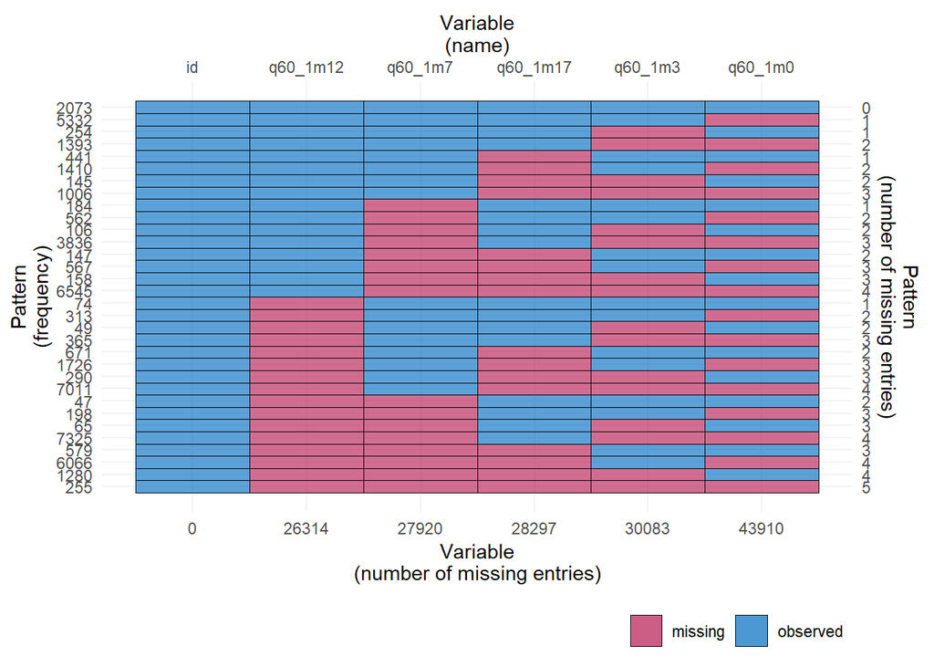

```r
plot_pattern(dat_wide[, c("id", "q60_1m0", "q60_1m3", "q60_1m7", "q60_1m12", "q60_1m17")], square = FALSE)
```

```r
n_mis <- rowSums(is.na(dat_wide[, c("q60_1m0", "q60_1m3", "q60_1m7", "q60_1m12", "q60_1m17")]))
ids <- dat_wide[n_mis < 4, "id"]
save(ids, file = "../Data/remeasured_cases.Rdata")
```

Now we need to load the imputed data and select the cases with two or more measurements.

```r
dat_remeasured <- long_subset[long_subset$id %in% ids$id, ]
imp_post2 <- as.mids(dat_remeasured)
```

## 6.1 Analysis 1: Model with Time

```r
fit <- imp_post2 %>%
  complete("all") %>%
  map(~.x %$% lme4::lmer(q60_1 ~ meting_mnd +  (1|id)))
# First imputed set
fit[[1]] %>% summary() %>% print(correlation = TRUE)
# Summary AIC
fit %>% map(~.x %>% AIC()) %>% unlist() %>% summary()
# Pooled imputations
fit %>%
  pool() %>%
  broom.mixed::tidy()
results_vert <- mitml::testEstimates(as.mitml.result(fit), extra.pars = TRUE)
results_vert
```

## 6.2 Analysis 2: Model with time-independent predictors added

```r
fit <- imp_post2 %>%
  complete("all") %>%
  map(~.x %$% lme4::lmer(q60_1 ~ meting_mnd + age + sekse + etn_herkomst + edu + huis + (1|id)))
# First imputed set
fit[[1]] %>% summary() %>% print(correlation = TRUE)
# Summary AIC
fit %>% map(~.x %>% AIC()) %>% unlist() %>% summary()
# Pooled imputations
fit %>%
  pool() %>%
  broom.mixed::tidy()
results_vert <- mitml::testEstimates(as.mitml.result(fit), extra.pars = TRUE)
results_vert
```

## 6.3 Analysis 3: Model with time-dependent predictors added

```r
fit <- imp_post2 %>%
  complete("all") %>%
  map(~.x %$% lme4::lmer(q60_1 ~ meting_mnd + age + sekse + etn_herkomst + edu + huis + (1|id) + gezo + rond + medi + hulp + eenz + cont + drei + onvr + econ + ment))
# First imputed set
fit[[1]] %>% summary() %>% print(correlation = TRUE)
# Summary AIC
fit %>% map(~.x %>% AIC()) %>% unlist() %>% summary()
# Pooled imputations
fit %>%
  pool() %>%
  broom.mixed::tidy()
results_vert <- mitml::testEstimates(as.mitml.result(fit), extra.pars = TRUE)
results_vert
```

# 7 Weighted averages

Compute weighted averages per time point (Figuur 2).

```r
imp_post %>%
  mice::complete("long") %>%
  group_by(meting_mnd) %>%
  summarise(vertrouwen = weighted.mean(q60_1, weegfactor, na.rm = TRUE),
            onvrede = weighted.mean(onvr, weegfactor, na.rm = TRUE),
            dreiging = weighted.mean(drei, weegfactor, na.rm = TRUE),
            rondkomen = weighted.mean(rond, weegfactor, na.rm = TRUE),
            gezondheid = weighted.mean(gezo, weegfactor, na.rm = TRUE)
            )
```

```
## # A tibble: 5 × 6
##   meting_mnd vertrouwen onvrede dreiging rondkomen gezondheid
##        <dbl>      <dbl>   <dbl>    <dbl>     <dbl>      <dbl>
## 1          0       3.51    2.07     2.91      2.35       2.36
## 2          3       3.43    2.36     2.92      2.35       2.16
## 3          7       3.31    2.60     3.01      2.36       2.08
## 4         12       3.04    2.80     2.87      2.34       2.08
## 5         17       2.59    2.67     2.62      2.34       2.14
```

# 8 Demographics re-measured cases

Bereken de groepsgemiddelden voor participanten die een keer versus meermaal hebben deelgenomen.

```r
set.seed(1)
# load("../Data/remeasured_cases.Rdata")

# add indicator for cases with more than once measurement
long_remeasure_indicator <- imp_post %>%
  mice::complete("long", include = TRUE) %>%
  mutate(remeasured = factor(id %in% ids$id, levels = c(TRUE, FALSE), labels = c(">1", "once")))

# compute weighted averages split by the measurements indicator
long_remeasure_indicator %>%
  group_by(remeasured) %>%
  summarise(leeftijd = weighted.mean(age, weegfactor, na.rm = TRUE),
            gender_num = weighted.mean(as.numeric(sekse), weegfactor, na.rm = TRUE),
            opleiding_num = weighted.mean(as.numeric(edu), weegfactor, na.rm = TRUE),
            vertrouwen = weighted.mean(q60_1, weegfactor, na.rm = TRUE),
            onvrede = weighted.mean(onvr, weegfactor, na.rm = TRUE),
            dreiging = weighted.mean(drei, weegfactor, na.rm = TRUE),
            rondkomen = weighted.mean(rond, weegfactor, na.rm = TRUE),
            gezondheid = weighted.mean(gezo, weegfactor, na.rm = TRUE)
            )
```

```
## # A tibble: 2 × 9
##   remeasured leeftijd gender_num opleiding_num vertrouwen onvrede dreiging
##   <fct>         <dbl>      <dbl>         <dbl>      <dbl>   <dbl>    <dbl>
## 1 >1             50.9       1.48          1.54       3.24    2.45     2.94
## 2 once           45.0       1.53          1.57       3.14    2.53     2.83
## # ℹ 2 more variables: rondkomen <dbl>, gezondheid <dbl>
```

```r
# test differences in demographics for cases with one or more measurements
# for clarity on the 'incomplete' data, because demographics are completely observed
dat_remeasure_ind <- long_remeasure_indicator[long_remeasure_indicator$.imp == 0, ]

# opleiding
table(dat_remeasure_ind$edu, dat_remeasure_ind$remeasured)
```

```
##
##              >1   once
##   Hoog    81050 109105
##   Middel  23755  25585
##   Laag     5150   7720
```

```r
prop.table(table(dat_remeasure_ind$edu, dat_remeasure_ind$remeasured))
```

```
##
##                  >1       once
##   Hoog   0.32116181 0.43233016
##   Middel 0.09412953 0.10138094
##   Laag   0.02040695 0.03059061
```

```r
chisq.test(dat_remeasure_ind$edu, dat_remeasure_ind$remeasured)
```

```
##
##  Pearson's Chi-squared test
##
## data:  dat_remeasure_ind$edu and dat_remeasure_ind$remeasured
## X-squared = 555.61, df = 2, p-value < 2.2e-16
```

```r
# gender
table(dat_remeasure_ind$sekse, dat_remeasure_ind$remeasured)
```

```
##
##            >1  once
##   Man   68210 77740
##   Vrouw 41745 64670
```

```r
prop.table(table(dat_remeasure_ind$sekse, dat_remeasure_ind$remeasured), margin = 2) %>% round(., 2)
```

```
##
##           >1 once
##   Man   0.62 0.55
##   Vrouw 0.38 0.45
```

```r
chisq.test(dat_remeasure_ind$sekse, dat_remeasure_ind$remeasured)
```

```
##
##  Pearson's Chi-squared test with Yates' continuity correction
##
## data:  dat_remeasure_ind$sekse and dat_remeasure_ind$remeasured
## X-squared = 1410.2, df = 1, p-value < 2.2e-16
```

```r
# leeftijd
dat_remeasure_ind %>%
  group_by(remeasured) %>%
  summarise(leeftijd = mean(age))
```

```
## # A tibble: 2 × 2
##   remeasured leeftijd
##   <fct>         <dbl>
## 1 >1             56.2
## 2 once           52.9
```

```r
t.test(dat_remeasure_ind$age ~ dat_remeasure_ind$remeasured)
```

```
##
##  Welch Two Sample t-test
##
## data:  dat_remeasure_ind$age by dat_remeasure_ind$remeasured
## t = 52.25, df = 240272, p-value < 2.2e-16
## alternative hypothesis: true difference in means between group >1 and group once is not equal to 0
## 95 percent confidence interval:
##  3.192918 3.441797
## sample estimates:
##   mean in group >1 mean in group once
##           56.20058           52.88322
```

Bereken de groepsgemiddelden voor participanten die één keer hebben deelgenomen versus participanten die meermaals gemeten zijn, gewogen naar ‘weegfactor’.

```r
# leeftijd gewogen
dat_remeasure_ind %>%
  group_by(remeasured) %>%
  summarise(leeftijd = weighted.mean(age, weegfactor)) %>%
  t()
```

```
##            [,1]       [,2]
## remeasured ">1"       "once"
## leeftijd   "50.93392" "44.99411"
```

```r
summary(aov(age ~ remeasured, data = dat_remeasure_ind, weight = weegfactor))
```

```
##                 Df   Sum Sq Mean Sq F value Pr(>F)
## remeasured       1  1708950 1708950    6756 <2e-16 ***
## Residuals   252363 63834087     253
## ---
## Signif. codes:  0 '***' 0.001 '**' 0.01 '*' 0.05 '.' 0.1 ' ' 1
```

```r
# opleiding gewogen
hardhat::weighted_table(dat_remeasure_ind$edu, dat_remeasure_ind$remeasured, weights = dat_remeasure_ind$weegfactor, na_remove = FALSE)
```

```
##               >1     once
## Hoog   40849.823 82142.20
## Middel 24448.794 42886.62
## Laag    7474.502 19821.09
```

```r
prop.table(hardhat::weighted_table(dat_remeasure_ind$edu, dat_remeasure_ind$remeasured, weights = dat_remeasure_ind$weegfactor, na_remove = FALSE), margin = 2) %>% round(., 2)
```

```
##          >1 once
## Hoog   0.56 0.57
## Middel 0.34 0.30
## Laag   0.10 0.14
```

```r
weights::wtd.chi.sq(dat_remeasure_ind$edu, dat_remeasure_ind$remeasured, weight = dat_remeasure_ind$weegfactor)
```

```
##         Chisq            df       p.value
##  8.136961e+02  2.000000e+00 2.032979e-177
```

```r
# gender gewogen
hardhat::weighted_table(dat_remeasure_ind$sekse, dat_remeasure_ind$remeasured, weights = dat_remeasure_ind$weegfactor, na_remove = FALSE)
```

```
##             >1     once
## Man   37809.91 68796.03
## Vrouw 34963.21 76053.88
```

```r
prop.table(hardhat::weighted_table(dat_remeasure_ind$sekse, dat_remeasure_ind$remeasured, weights = dat_remeasure_ind$weegfactor, na_remove = FALSE), margin = 2) %>% round(., 2)
```

```
##         >1 once
## Man   0.52 0.47
## Vrouw 0.48 0.53
```

```r
weights::wtd.chi.sq(dat_remeasure_ind$sekse, dat_remeasure_ind$remeasured, weight = dat_remeasure_ind$weegfactor)
```

```
##        Chisq           df      p.value
## 4.473469e+02 1.000000e+00 2.725846e-99
```